# Topic 5: Word Relationships

Steven Cognac

2022-04-27

```r
library(tidyr) #text analysis in R
library(pdftools)
library(lubridate) #working with date data
library(tidyverse)
library(tidytext)
library(readr)
library(quanteda)
library(readtext) #quanteda subpackage for reading pdf
library(quanteda.textstats)
library(quanteda.textplots)
library(ggplot2)
library(forcats)
library(stringr)
library(quanteda.textplots)
library(widyr)# pairwise correlations
library(igraph) #network plots
library(ggraph)
library(here)
library(rmarkdown)
```

# Import data

```r
# I've downloaded all the PDFs to a local drive for this
files <- list.files(path = here("05_EPA_txt_analysis"), pattern = "pdf$", full.names = T)

ej_reports <- lapply(files, pdf_text)

ej_pdf <- readtext("*.pdf", docvarsfrom = "filenames",
                    docvarnames = c("type", "year"),
                    sep = "_")
# creating an initial corpus containing our data
epa_corp <- corpus(x = ej_pdf, text_field = "text" )
summary(epa_corp)
```

```
## Corpus consisting of 6 documents, showing 6 documents:
##
##             Text Types Tokens Sentences type year docvar3
##  EPA_EJ_2015.pdf  2136   8944       263  EPA   EJ    2015
##  EPA_EJ_2016.pdf  1599   7965       176  EPA   EJ    2016
##  EPA_EJ_2017.pdf  3973  30564       653  EPA   EJ    2017
##  EPA_EJ_2018.pdf  2774  16658       447  EPA   EJ    2018
##  EPA_EJ_2019.pdf  3773  22648       672  EPA   EJ    2019
##  EPA_EJ_2020.pdf  4493  30523       987  EPA   EJ    2020
```

```r
# Let's adding some additional, context-specific stop words to stop word lexicon
more_stops <-c("2015",
               "2016",
               "2017",
               "2018",
               "2019",
               "2020",
               "www.epa.gov",
               "https")

add_stops<- tibble(word = c(stop_words$word, more_stops))
stop_vec <- as_vector(add_stops)
```

# Part 1. What are the most frequent trigrams in the dataset? How does this compare to the most frequent bigrams? Which n-gram seems more informative here, and why?

```r
# output is a list of vectors
tokens <- tokens(epa_corp, remove_punct = TRUE)

# some token cleaning
toks1 <- tokens_select(tokens, min_nchar = 3)
toks1 <- tokens_tolower(toks1)
toks1 <- tokens_remove(toks1, pattern = (stop_vec))

# two words is a "bi-gram" "two-word pairs" as a fundamental unit of analysis
toks2 <- tokens_ngrams(toks1, n=2)
toks3 <- tokens_ngrams(toks1, n=3)

# create document feature matrix from tokens
# rows refer to number of occurrences within entire corpus in entire document
dfm2 <- dfm(toks2)
dfm2 <- dfm_remove(dfm2, pattern = c(stop_vec))

dfm3 <- dfm(toks3)
dfm3 <- dfm_remove(dfm3, pattern = c(stop_vec))

# calculate basic statistics
freq_words2 <- textstat_frequency(dfm2, n=20, groups = year)
freq_words2$token <- rep("bigram", 20)

freq_words3 <- textstat_frequency(dfm3, n=20, groups = year)
freq_words3$token <- rep("trigram", 20)
```

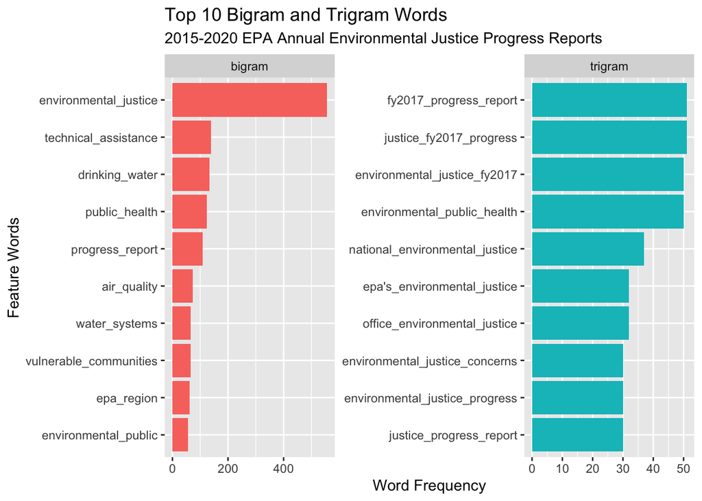

```r
freq_compare <- rbind(freq_words3 %>% slice_max(frequency, n = 10),
                      freq_words2 %>% slice_max(frequency, n = 10)) %>%
  mutate(order = reorder_within(feature, frequency, token))

freq_compare %>%
  ggplot(aes(y = reorder(feature, desc(frequency)), x = frequency)) +
  geom_col(aes(fill = token)) +
  facet_wrap(~token, scales = "free") +
  labs(y = "Feature Words",
       x = "Word Frequency",
       title = "Top 10 Bigram and Trigram Words",
       subtitle = "2015-2020 EPA Annual Environmental Justice Progress Reports") +
  scale_y_discrete(limits=rev) +
  theme(legend.position="none")
```

# Part 2. Choose a new focal term to replace “justice” and recreate the correlation table and network (see corr_paragraphs and corr_network chunks). Explore some of the plotting parameters in the cor_network chunk to see if you can improve the clarity or amount of information your plot conveys. Make sure to use a different color for the ties!

```r
#convert to tidy format and apply my stop words
raw_text <- tidy(epa_corp)

#Distribution of most frequent words across documents
raw_words <- raw_text %>%
  mutate(year = as.factor(year)) %>%
  unnest_tokens(word, text) %>%
  anti_join(add_stops, by = 'word') %>%
  count(year, word, sort = TRUE)

#number of total words by document
total_words <- raw_words %>%
  group_by(year) %>%
  summarize(total = sum(n))

report_words <- left_join(raw_words, total_words)
```

```r
# tokenizing to the "paragraph" level
# helps extract meaning from words by attaching a paragraph ID
par_tokens <- unnest_tokens(raw_text, output = paragraphs, input = text, token = "paragraphs")

par_tokens <- par_tokens %>%
 mutate(par_id = 1:n())

par_words <- unnest_tokens(par_tokens, output = word, input = paragraphs, token = "words")
```

```r
# create correlations between words
word_cors <- par_words %>%
  add_count(par_id) %>%
  filter(n >= 50) %>%
  select(-n) %>%
  pairwise_cor(word, par_id, sort = TRUE)
```

Word of interest: “energy”

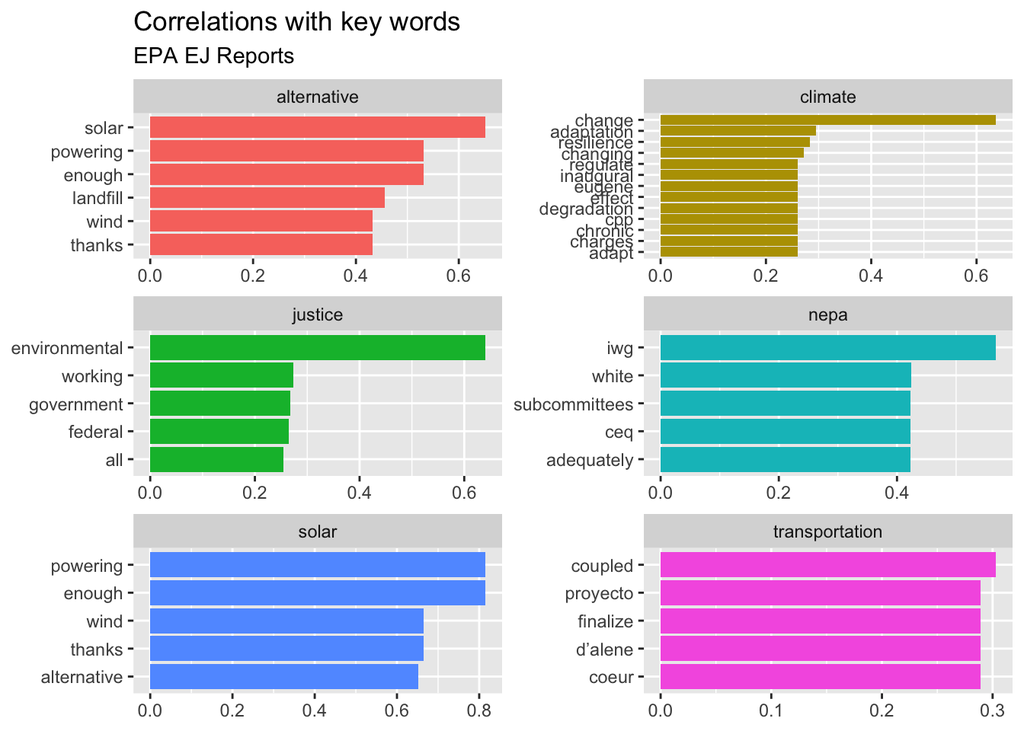

```r
# select correlations that contain "energy"
energy_cors <- word_cors %>%
  filter(item1 == "energy")

# filtering words in the context of `item1`
word_cors_df <- word_cors %>%
  filter(item1 %in% c("climate",
                      "transportation",
                      "nepa",
                      "alternative",
                      "solar",
                      "justice")) %>%
  group_by(item1) %>%
  slice_max(correlation, n=5) %>%
  ungroup() %>%
  mutate(item1 = as.factor(item1),
  name = reorder_within(item2, correlation, item1))

ggplot(word_cors_df, aes(y = name, x = correlation, fill = item1)) +
  geom_col(show.legend = FALSE) +
  facet_wrap(~item1, ncol = 2, scales = "free")+
  scale_y_reordered() +
  labs(y = NULL,
       x = NULL,
       title = "Correlations with key words",
       subtitle = "EPA EJ Reports")
```

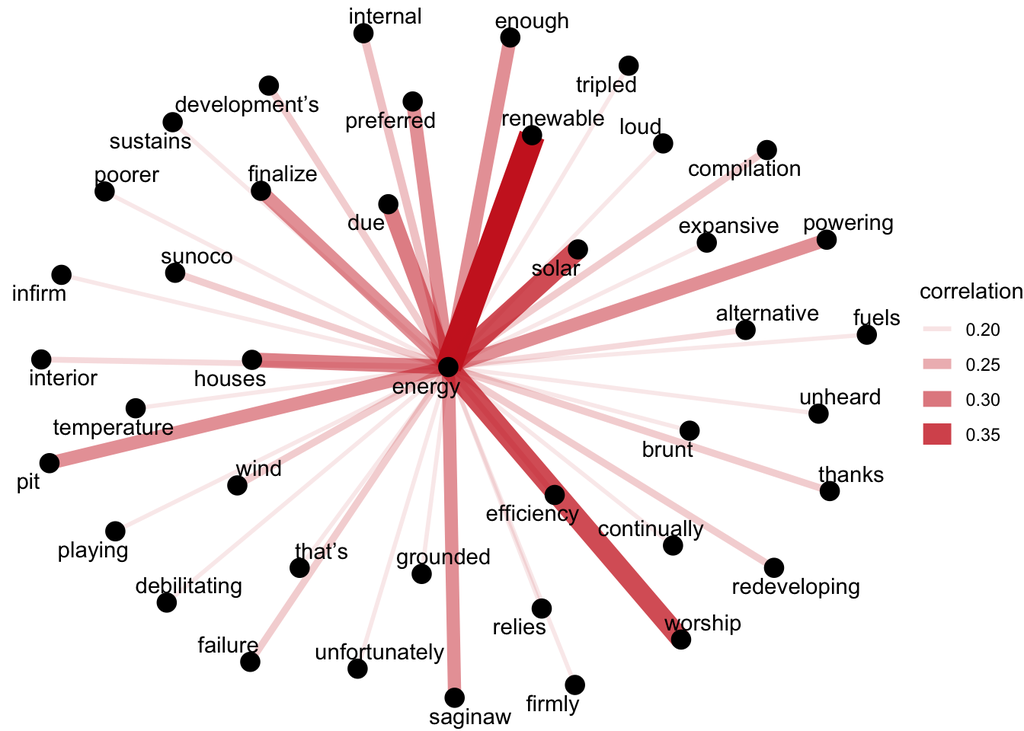

```r
# let's zoom in on just one of our key terms
energy_cors <- word_cors %>%
  filter(item1 == "energy") %>%
  mutate(n = 1:n())

energy_cors  %>%
  filter(n <= 40) %>%
  graph_from_data_frame() %>%
  ggraph(layout = "fr") +
  geom_edge_link(aes(edge_alpha = correlation, edge_width = correlation), edge_colour = "firebrick3") +
  geom_node_point(size = 4) +
  geom_node_text(aes(label = name), repel = TRUE,
                 point.padding = unit(0.2, "lines")) +
  theme_void()
```

Not surprisingly, we see “renewable energy” and “solar energy” as our most highly correlated word pairs. One surprising correlation is “worship” and energy.

# Part 3. Write a function that allows you to conduct a keyness analysis to compare two individual EPA reports (hint: that means target and reference need to both be individual reports). Run the function on 3 pairs of reports, generating 3 keyness plots.

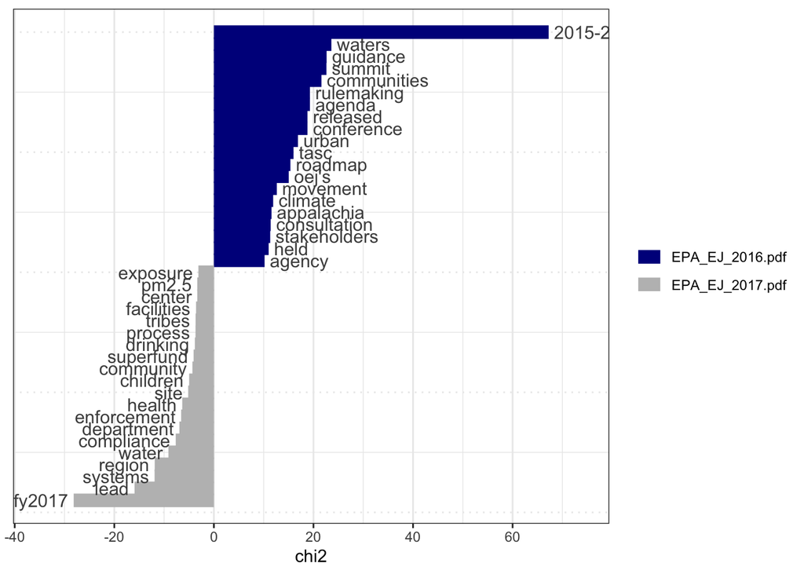

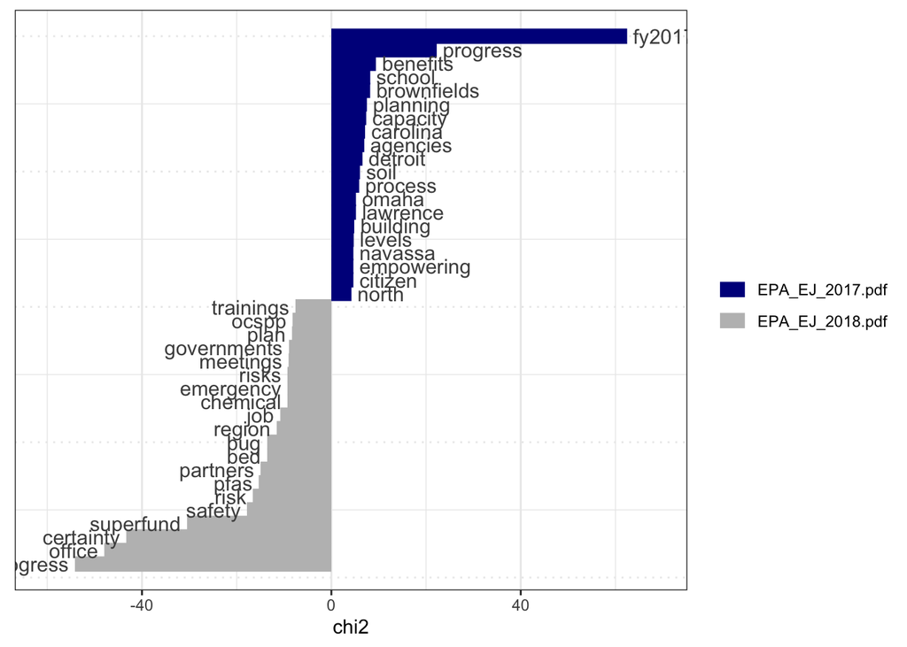

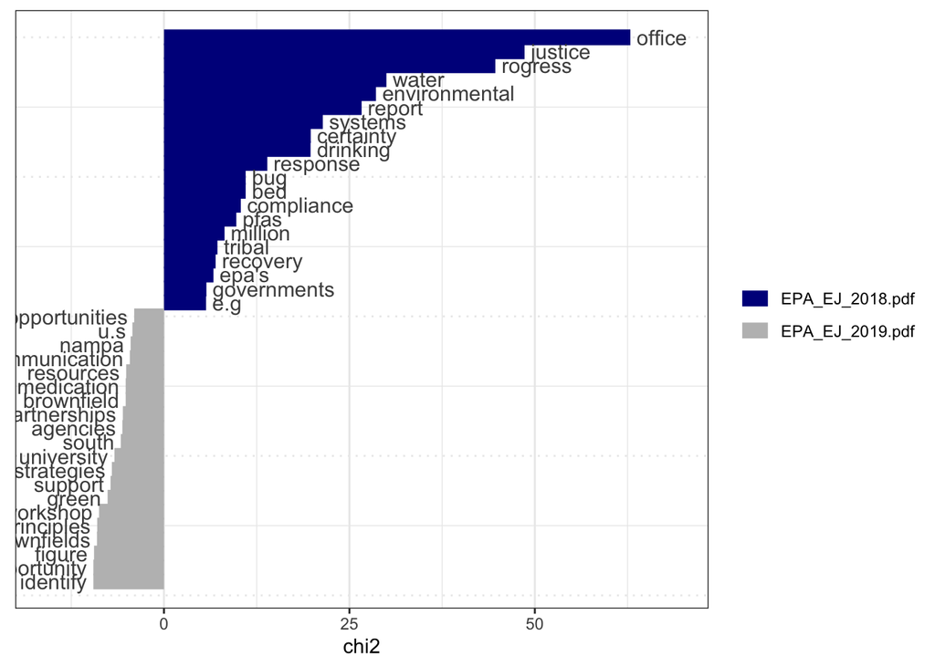

```r
keyness_fn <- function(){
  for (i in 2:4) {
    reports <- epa_corp[i:(i+1)]
    reps_tok <- tokens(reports, remove_punct = TRUE)
    reps <- tokens_select(reps_tok, min_nchar = 3) %>%
      tokens_tolower() %>%
      tokens_remove(pattern = (stop_vec))
    dfm <- dfm(reps)
    keyness <- textstat_keyness(dfm, target = 1)
    print(textplot_keyness(keyness))
  }
}
keyness_fn()
```

# Part 4. Select a word or multi-word term of interest and identify words related to it using windowing and keyness comparison. To do this you will create to objects: one containing all words occurring within a 10-word window of your term of interest, and the second object containing all other words. Then run a keyness comparison on these objects. Which one is the target, and which the reference? [Hint](https://tutorials.quanteda.io/advanced-operations/target-word-collocations/)

```r
term <- c("water")

# words within a 10-word window of "water"
toks_inside <- tokens_keep(tokens, pattern = term, window = 10) %>%
  tokens_remove(pattern = term) %>% # remove the keywords
  tokens_tolower() %>%
  tokens_remove(pattern = c(stop_vec))

dfm_inside <- dfm(toks_inside)

# words outside a 10-word window of "water"
toks_outside <- tokens_remove(tokens, pattern = term, window = 10) %>%
  tokens_tolower() %>%
  tokens_remove(pattern = c(stop_vec))

dfm_outside <- dfm(toks_outside)

# combine datasets
dfm_inside_outside <- rbind(dfm_inside, dfm_outside)

# compute associations with keywords
keyness2 <- textstat_keyness(dfm_inside_outside, target = seq_along(ndoc(dfm_inside)))

paged_table(keyness2)
```

| feature | chi2 | p | n_target | n_reference |
| --- | --- | --- | --- | --- |
| 130 | 9.942090e+01 | 0.000000e+00 | 1 | 0 |
| 600,000 | 9.942090e+01 | 0.000000e+00 | 1 | 0 |
| lay- | 9.942090e+01 | 0.000000e+00 | 1 | 0 |
| sole | 9.942090e+01 | 0.000000e+00 | 1 | 0 |
| stable | 9.942090e+01 | 0.000000e+00 | 1 | 0 |
| treaties | 9.942090e+01 | 0.000000e+00 | 1 | 0 |
| source | 5.353376e+01 | 2.542411e-13 | 2 | 14 |
| flooding | 5.021352e+01 | 1.378897e-12 | 2 | 15 |
| improved | 5.021352e+01 | 1.378897e-12 | 2 | 15 |
| happen | 4.921383e+01 | 2.295275e-12 | 1 | 1 |

[output cut: 6387 more lines]